# GERMINACIÓN DE SEMILLAS DE LUPINO (*Lupino mutabilis*) EXPUESTAS A DOS MÉTODOS DE ESCARIFICACIÓN FÍSICA

Author

Erik Vilchez, Lleyner Roman, Elda Perez, Deyli Fernandez, Griselida Rojas, Erick Vasquez

# 1 INTRODUCCIÓN

Las semillas de lupino (Lupinus sp.) presentan dormancia física que impide su germinación, debido a la dureza e impermeabilidad de la testa (Garduza et al., 2020). Para superar esta barrera, se aplican métodos de escarificación física como el lijado y el corte con bisturí, los cuales han demostrado mejorar significativamente la germinación y sincronización en especies como L. perennis y L. exaltatus (Steinmaus et al., 2000; Mackay et al., 1996). Estos tratamientos también se asocian con mayor actividad enzimática en etapas iniciales (Garduza et al., 2019). En un estudio sobre Lupinus bilineatus, la escarificación mecánica mediante lijado con papel de lija resultó en un 48.9 % de germinación, cifra significativamente superior al control sin tratamiento. Este tratamiento no sólo rompió la impermeabilidad de la testa, sino que, al exponer las capas internas del endospermo, facilitó la imbibición y permitió que las enzimas hidrolíticas actúen con mayor rapidez en los primeros días de germinación, mejorando la energía germinativa y la uniformidad en el desarrollo de la plántula (Pascual et al., 2020).

# 2 OBJETIVOS

## 2.1 Objetivo general

Determinar la germinación de Lupinus sp mediante dos técnicas de escarificación física.

## 2.2 Objetivos específicos

- Analizar el porcentaje de germinación de semillas de lupino sometidas a escarificación por lijado de la testa y por corte con bisturí.
- Determinar el índice de sincronización de la germinación de semillas de lupino mediante ambos métodos de escarificación.
- Comparar el tiempo medio de germinación de semillas de lupino según el tipo de escarificación aplicada.

# 3 MATERIALES Y MÉTODOS

## 3.1 Materiales:

- Semillas de chocho (Lupinus sp.)
- Lijas
- Bisturíes
- Papel toalla
- Taper o recipiente
- Guantes
- Ligas
- Pinzas
- Agua mineral

## 3.2 Metodología

**Obtención de semillas**

Se obtuvo 1 kg de semillas de chocho (Lupinus sp) provenientes de la provincia de Luya, distrito Lamud.

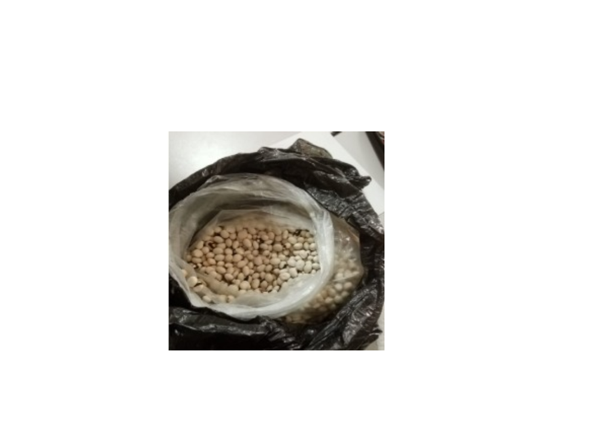

Mi imagen desde Google Drive

**Elaboración de las etiquetas**

Para identificar los tratamientos se elaboraron etiquetas en R con sus respectivas leyendas (lijado, bisturí y control), lo que facilitó un seguimiento organizado y preciso del comportamiento de cada grupo de semillas.

[figure not shown]

Imagen actualizada desde Google Drive

**Selección de semillas.**

Las semillas fueron seleccionadas cuidadosamente, asegurándose de que no presentaran defectos como daños por plagas o un tamaño excesivamente reducido. Posteriormente, se aplicaron dos métodos físicos de escarificación: a 100 semillas se les lijó la testa (abrasión mecánica) y a otras 100 se les realizó un corte en la testa utilizando un bisturí. Además, se seleccionaron cuatro repeticiones de 25 semillas cada una para el tratamiento control.

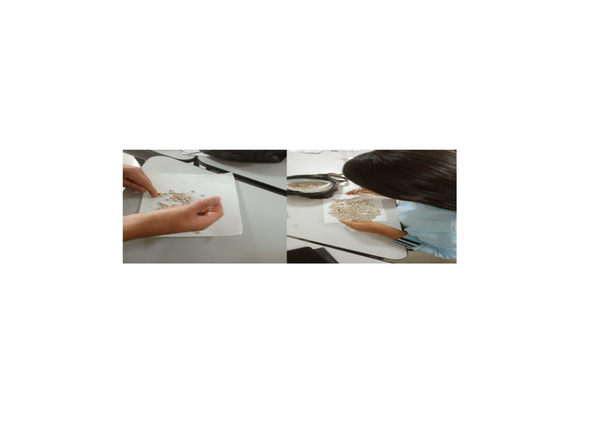

Imagen actualizada desde Google Drive

**Preparación de recipientes.**

El experimento se desarrolló haciendo uso de 12 recipientes de plástico, de tal manera que estén divididos en tres tratamientos: 4 recipientes para el método físicos de escarificación por lijado, 4 recipientes para corte de la testa con bisturí y 4 recipientes como control. En la base de los recipientes se colocó papel toalla y se humedeció con agua.Luego se procedió a lijar las semillas del tratamiento de escarificación con lija de la cual se tenía 4 repeticiones, De igual manera se procedió a cortar una parte de la semilla con el bisturí que correspondía al tratamiento con bisturí que también tenía 4 repeticiones.

Y del tratamiento 3 que era el control solo se colocó en los taperes correspondientes sin ser sometidos a ningún método de escarificación.

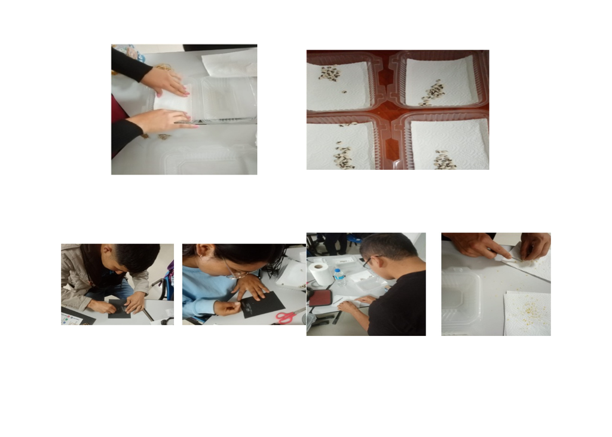

**Organización de semillas.**

Se colocaron 25 semillas por recipiente, distribuidas de forma ordenada para facilitar su observación y análisis.

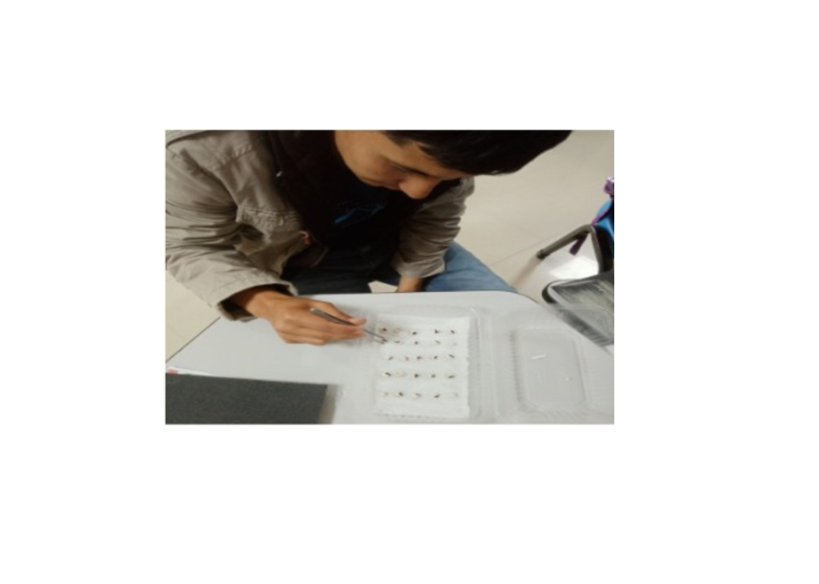

Imagen actualizada desde Google Drive

**Variables a evaluar**

**Variable independiente:**

Tipos de escarificación (lijado de la testa y corte con bisturí)

**Variable dependiente:**

- Porcentaje de germinación de semillas
- Índice de sincronización de la germinación de semillas.
- Tiempo medio de germinación de semillas

**Diseño del experimento**

**Tratamientos**

- T1: Escarificación por lijado o abrasión mecánica.
- T2: Escarificación por corte de la testa con bisturí.
- T3: Control

**Repeticiones**

```
4 repeticiones por tratamiento.
```

**Número de semillas por repetición**

```
25 semillas por repetición.
```

**Diseño estadístico**

```
    Diseño de Bloques Completos al Azar (DBCA).
```

**Evaluación de las semillas germinadas**

La evaluación fue diaria iniciando del día 0, hasta el día 5, registrando los datos de manera continua la aparición de signos de germinación y cualquier cambio relevante en su desarrollo. Durante este periodo, se controló cuidadosamente el nivel de humedad y se mantuvieron constantes las condiciones ambientales, para así evaluar con cuál de los métodos de escarificación las semillas logran germinar en menor tiempo.

# 4 RESULTADOS

‘data.frame’: 12 obs. of 8 variables: $ plots : Factor w/ 12 levels “101”,“102”,“103”,..: 5 7 9 10 6 8 11 12 1 2 … $ Tratamiento: Factor w/ 3 levels “Bisturí”,“Control”,..: 1 1 1 1 3 3 3 3 2 2 … $ seeds : num 25 25 25 25 25 25 25 25 25 25 … $ d0 : num 0 0 0 0 0 0 0 0 0 0 … $ d1 : num 5 2 3 0 2 9 4 7 0 0 … $ d2 : num 6 8 4 15 7 3 7 6 16 2 … $ d3 : num 9 13 6 3 15 8 13 7 0 16 … $ d5 : num 2 0 7 2 0 1 0 2 4 7 …

| plots | Tratamiento | seeds | grs | grp | mgt | mgr | gsp | unc | syn | vgt | sdg | cvg |
| --- | --- | --- | --- | --- | --- | --- | --- | --- | --- | --- | --- | --- |
| 105 | Bisturí | 25 | 22 | 88 | 2.454546 | 0.4074074 | 40.74074 | 1.8390343 | 0.2683983 | 0.9177489 | 0.9579921 | 39.02931 |
| 107 | Bisturí | 25 | 23 | 92 | 2.478261 | 0.4035088 | 40.35088 | 1.3015743 | 0.4229249 | 0.4426877 | 0.6653478 | 26.84737 |
| 109 | Bisturí | 25 | 20 | 80 | 3.200000 | 0.3125000 | 31.25000 | 1.9261207 | 0.2368421 | 1.3157895 | 1.1470787 | 35.84621 |
| 110 | Bisturí | 25 | 20 | 80 | 2.450000 | 0.4081633 | 40.81633 | 1.0540158 | 0.5736842 | 0.4605263 | 0.6786209 | 27.69881 |
| 106 | Lijado | 25 | 24 | 96 | 2.541667 | 0.3934426 | 39.34426 | 1.2410107 | 0.4601449 | 0.4329710 | 0.6580053 | 25.88873 |
| 108 | Lijado | 25 | 21 | 84 | 2.095238 | 0.4772727 | 47.72727 | 1.6644978 | 0.3190476 | 1.0500000 | 1.0246951 | 48.90590 |
| 111 | Lijado | 25 | 24 | 96 | 2.375000 | 0.4210526 | 42.10526 | 1.4284125 | 0.3804348 | 0.5923913 | 0.7696696 | 32.40714 |
| 112 | Lijado | 25 | 22 | 88 | 2.272727 | 0.4400000 | 44.00000 | 1.8770342 | 0.2510823 | 1.0216450 | 1.0107646 | 44.47364 |
| 101 | Control | 25 | 20 | 80 | 2.600000 | 0.3846154 | 38.46154 | 0.7219281 | 0.6631579 | 0.7157895 | 0.8460434 | 32.54013 |
| 102 | Control | 25 | 25 | 100 | 3.480000 | 0.2873563 | 28.73563 | 1.2177968 | 0.4733333 | 0.4150000 | 0.6442049 | 18.51164 |
| 103 | Control | 25 | 24 | 96 | 3.500000 | 0.2857143 | 28.57143 | 0.8112781 | 0.6086957 | 0.2608696 | 0.5107539 | 14.59297 |
| 104 | Control | 25 | 22 | 88 | 3.727273 | 0.2682927 | 26.82927 | 0.9456603 | 0.5151515 | 0.3809524 | 0.6172134 | 16.55938 |

## 4.1 Tiempo medio de germinaión

En la barra verde (Bisturí), el tiempo promedio de germinación es cercano a 2.7 días, en cambio en la barra roja que corresponde al tratamiento por lijado el tiempo es ligeramente menor, llegando a 2.4 días aproximadamente. Además, comparten la misma letra “b”, indicando que no existe diferencia estadísticamente entre ellos.

Analysis of Variance Table

Response: mgt Df Sum Sq Mean Sq F value Pr(>F)  
Tratamiento 2 2.1075 1.05373 7.5439 0.01191 * Residuals 9 1.2571 0.13968

Signif. codes: 0 ‘**’ 0.001 ’**’ 0.01 ’’ 0.05 ‘.’ 0.1 ’ ’ 1

Mean germination time comparison

| Tratamiento | mgt | std | r | ste | se | min | max | sig |
| --- | --- | --- | --- | --- | --- | --- | --- | --- |
| Bisturí | 2.645702 | 0.3697400 | 4 | 0.1848700 | 0.1868687 | 2.450000 | 3.200000 | b |
| Control | 3.326818 | 0.4973547 | 4 | 0.2486774 | 0.1868687 | 2.600000 | 3.727273 | a |
| Lijado | 2.321158 | 0.1870012 | 4 | 0.0935006 | 0.1868687 | 2.095238 | 2.541667 | b |

[figure not shown]

## 4.2 Germinabilidad

En los gráficos se observa una gráfica de barras donde compara el porcentaje de germinación grp (germinación relativa porcentual) en semillas de Lupinus sp. en los tres tratamientos empleados (bisturí, control y lijado), los mismos que están representados por la barra de color verde, amarillo rojo.

Las líneas negras que se encuentran sobre cada barra, representan la variabilidad de los datos; en este caso las barras son cortas indicando poca variabilidad demostrando resultados consistentes entre repeticiones.

Las letras que se observa sobre las barras (a), son las mismas es decir comparten la misma letra, lo que significa que no hay diferencias estadísticamente significativas entre tratamiento, pero si las letras fueran diferentes sería lo contrario.

Analysis of Variance Table

Response: grp Df Sum Sq Mean Sq F value Pr(>F) Tratamiento 2 96 48.000 0.9558 0.4203 Residuals 9 452 50.222

Mean germination time comparison

| Tratamiento | grp | std | r | ste | se | min | max | sig |
| --- | --- | --- | --- | --- | --- | --- | --- | --- |
| Bisturí | 85 | 6.000000 | 4 | 3.000000 | 3.543382 | 80 | 92 | a |
| Control | 91 | 8.869423 | 4 | 4.434712 | 3.543382 | 80 | 100 | a |
| Lijado | 91 | 6.000000 | 4 | 3.000000 | 3.543382 | 84 | 96 | a |

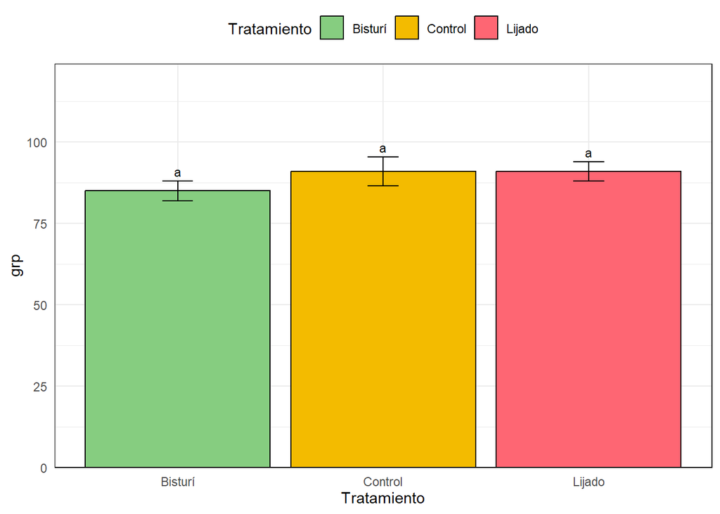